# chapter 2

22. Use the hist() function to produce some histograms withdiffering numbers of bins for a few of the quantitative variables. You may find the command par(mfrow=c(2,2)) useful:it will divide the print window into four regions so that fourplots can be made simultaneously. Modifying the arguments to this function will divide the screen in other ways.

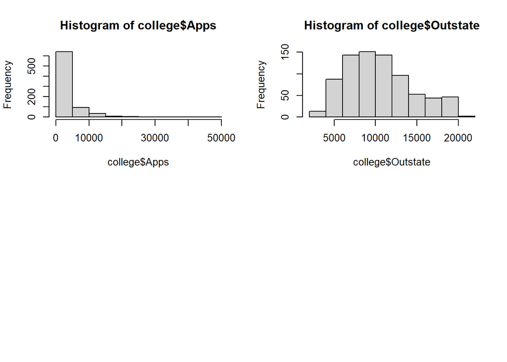

```r
par(mfrow=c(2,2))
hist(college$Apps)
hist(college$Outstate)
```

**INTERPRETAION** #The histogram shows a right-skewed distribution, indicating that most colleges receive a relatively low number of applications, with a few outliers #The histogram for out-of-state tuition is also be right-skewed, reflecting that most colleges charge a moderate amount for out-of-state tuition, while a few institutions have much higher fees. vi.Continue exploring the data, and provide a brief summary of what you discover

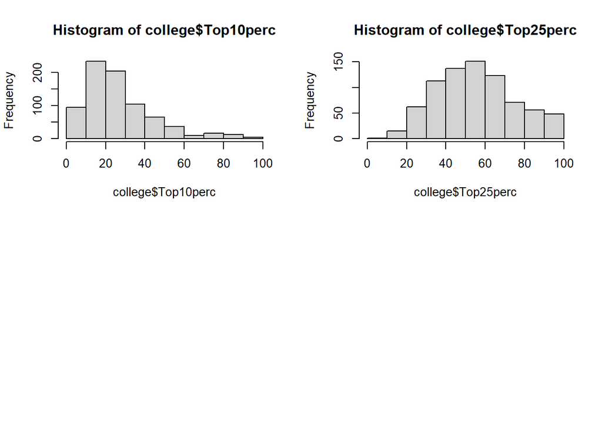

```r
par(mfrow=c(2,2))
hist(college$Top10perc)
hist(college$Top25perc)
```

**INTERPRETATION** #The histogram for Top10perc shoes a distribution that is slightly right-skewed, indicating that a moderate number of colleges have a high percentage of students from the top 10% of their high school classes. #the histogram for Top25perc shows the median percentage, indicating that many institutions enroll a considerable proportion of students from the top 25% of their high school class. #with a few elite institutions attracting high-achieving students, while the majority fall within a more moderate range

```r
fit = glm(Grad.Rate~., data = college)
fit
```

```
##
## Call:  glm(formula = Grad.Rate ~ ., data = college)
##
## Coefficients:
## (Intercept)   PrivateYes         Apps       Accept       Enroll    Top10perc
##  35.6911902    3.2753438    0.0013583   -0.0008132    0.0022046    0.0771177
##   Top25perc  F.Undergrad  P.Undergrad     Outstate   Room.Board        Books
##   0.0722750   -0.0004704   -0.0015117    0.0010057    0.0019374   -0.0024534
##    Personal          PhD     Terminal    S.F.Ratio  perc.alumni       Expend
##  -0.0016671    0.0776580   -0.0691915    0.0877899    0.2761555   -0.0004404
##    EliteYes
##   2.3526158
##
## Degrees of Freedom: 776 Total (i.e. Null);  758 Residual
## Null Deviance:       229000
## Residual Deviance: 123000    AIC: 6180
```

**INTERPRETATION** # a private institution (PrivateYes) is associated with a 3.28% higher graduation rate compared to public colleges # as a higher percentage of students from the top 10% and 25% of their high school class with coefficients of 0.077 and 0.072 #he decrease in deviance from 229,000 (null) to 123,000 (residual) indicates a substantial portion of the variation in graduation rates

#chapter-2(10) (a) To begin, load in the Boston data set. The Boston data set is part of the MASS library in R.

```r
library(MASS)
?Boston
```

```
## starting httpd help server ...
```

```
##  done
```

```r
dim(Boston)
```

```
## [1] 506  14
```

(b)Make some pairwise scatterplots of the predictors (columns) in this data set. Describe your findings.

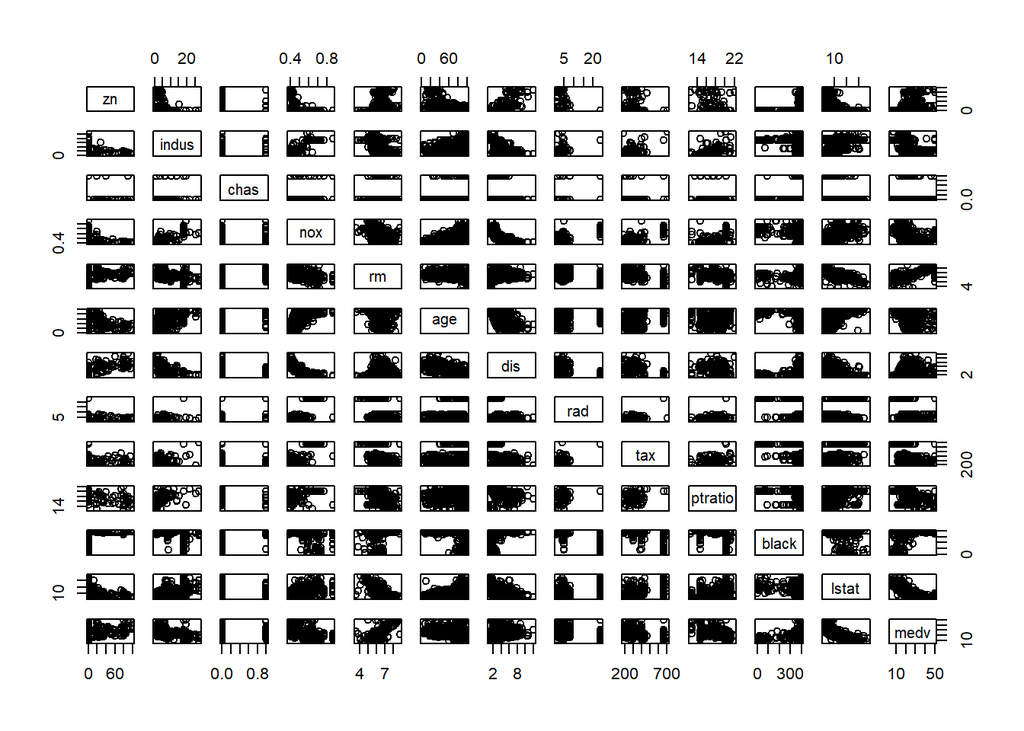

```r
 pairs(Boston[,2:14])
```

**INTERPRETATiON** #strong positive correlation between RM and MEDV indicates that larger homes #a negative correlation between the percentage of lower-status residents (LSTAT) and MEDV suggests that neighborhoods with more lower-status residents #such as NOXand INDUS, exhibit strong correlations